# task_1

praveen

9/2/2021

# THE SPARKS FOUNDADTION - TASK 1

## Linear Regression

In this section we will see how the machine learning can be used to implement regression functions. We will start with simple linear regression involving two variables.

## Simple Linear Regression

In this regression task we will predict the percentage of marks that a student is expected to score based upon the number of hours they studied. This is a simple linear regression task as it involves just two variables.

## Importing all libraries required in this dataset

```
  Load required packages
    ggplots2 for create plot
    tidyverse for data manipulation and visualization
    ggpubr creates easily a pubication ready-plot
        installed ggrepet for used ggpubr
```

```r
library(tidyverse)
library(ggplot2)
library(ggpubr)
```

## Load the datset by given the URL

Read the data sets that given for solving the problem.The given data set is based on students scores.

```r
data_task1 = read.csv("http://bit.ly/w-data")
data_task1
```

```
##    Hours Scores
## 1    2.5     21
## 2    5.1     47
## 3    3.2     27
## 4    8.5     75
## 5    3.5     30
## 6    1.5     20
## 7    9.2     88
## 8    5.5     60
## 9    8.3     81
## 10   2.7     25
## 11   7.7     85
## 12   5.9     62
## 13   4.5     41
## 14   3.3     42
## 15   1.1     17
## 16   8.9     95
## 17   2.5     30
## 18   1.9     24
## 19   6.1     67
## 20   7.4     69
## 21   2.7     30
## 22   4.8     54
## 23   3.8     35
## 24   6.9     76
## 25   7.8     86
```

## To insepct the data sets

To view the upper row of given data sets

```r
head(data_task1)
```

```
##   Hours Scores
## 1   2.5     21
## 2   5.1     47
## 3   3.2     27
## 4   8.5     75
## 5   3.5     30
## 6   1.5     20
```

To check deatil of data set.

```r
summary(data_task1)
```

```
##      Hours           Scores
##  Min.   :1.100   Min.   :17.00
##  1st Qu.:2.700   1st Qu.:30.00
##  Median :4.800   Median :47.00
##  Mean   :5.012   Mean   :51.48
##  3rd Qu.:7.400   3rd Qu.:75.00
##  Max.   :9.200   Max.   :95.00
```

## Plotting the distribution of scores

The column names that I used for plotting or visualizing is hours vs scores

## Scatter plot

Create Scatter plot for the hours and scores.

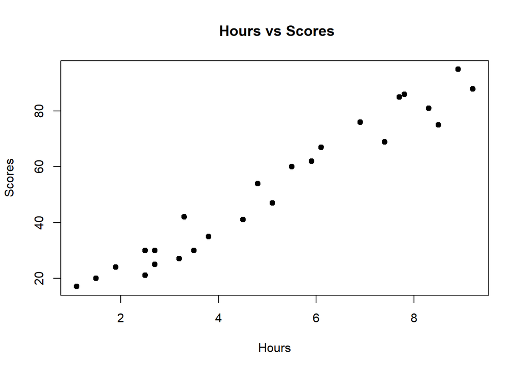

```r
plot(data_task1$Hours,data_task1$Scores,main = " Hours vs Scores", xlab = "Hours", ylab = "Scores" , pch=19)
```

From the graph above, we can clearly see that there is a positive linear relation between the number of hours studied and percentage of score.

## Building traning amd testing data

The next step is to divide the data into “attributes” (inputs) and “labels” (outputs).

```r
set.seed(123)
id_task1 <- sample(1:nrow(data_task1),0.7*nrow(data_task1))
id_train <- data_task1[id_task1,]
id_test  <- data_task1[-id_task1,]
```

## Training the Algorithm

```r
library(e1071)
model_task1 <- lm(Scores~Hours , data = data_task1)
summary(model_task1)
```

```
##
## Call:
## lm(formula = Scores ~ Hours, data = data_task1)
##
## Residuals:
##     Min      1Q  Median      3Q     Max
## -10.578  -5.340   1.839   4.593   7.265
##
## Coefficients:
##             Estimate Std. Error t value Pr(>|t|)
## (Intercept)   2.4837     2.5317   0.981    0.337
## Hours         9.7758     0.4529  21.583   <2e-16 ***
## ---
## Signif. codes:  0 '***' 0.001 '**' 0.01 '*' 0.05 '.' 0.1 ' ' 1
##
## Residual standard error: 5.603 on 23 degrees of freedom
## Multiple R-squared:  0.9529, Adjusted R-squared:  0.9509
## F-statistic: 465.8 on 1 and 23 DF,  p-value: < 2.2e-16
```

## Coefficients signifiance

```r
coefficients(model_task1)
```

```
## (Intercept)       Hours
##    2.483673    9.775803
```

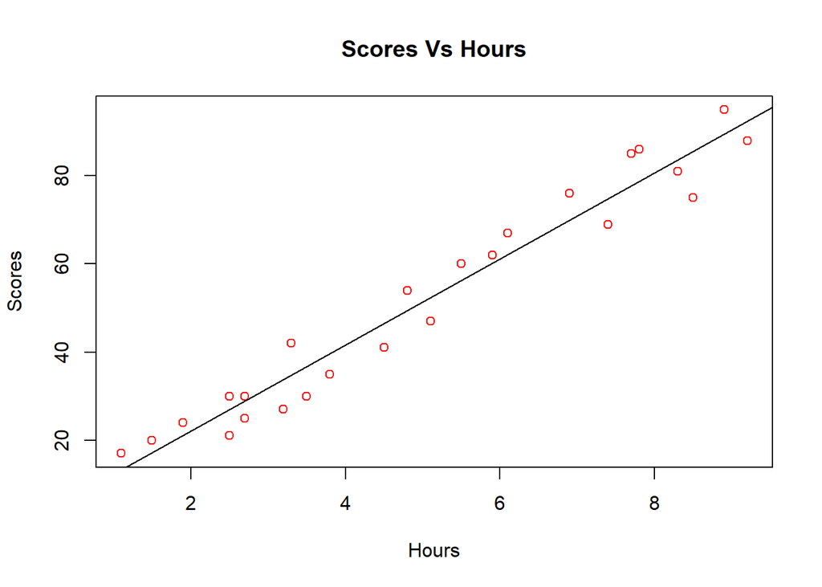

```r
plot(data_task1$Hours,data_task1$Scores,col="red",xlab = "Hours",ylab="Scores",main= "Scores Vs Hours")
abline(model_task1)
```

## Making Predictions

Now that we have trained our algorithm, it’s time to make some predictions.

```r
y_pred <- predict(model_task1,id_test)
y_pred
```

```
##        1        2        4        7        8       12       13       16
## 26.92318 52.34027 85.57800 92.42106 56.25059 60.16091 46.47479 89.48832
```

```r
df = data.frame(id_test$Scores,y_pred)
df
```

```
##    id_test.Scores   y_pred
## 1              21 26.92318
## 2              47 52.34027
## 4              75 85.57800
## 7              88 92.42106
## 8              60 56.25059
## 12             62 60.16091
## 13             41 46.47479
## 16             95 89.48832
```

## You can also test with your own data

```r
newhours <- data.frame(Hours=9.25)
predict_value <- predict(model_task1,newhours)
print(paste("No of Hours = ",newhours))
```

```
## [1] "No of Hours =  9.25"
```

```r
print(paste("Predicted Score = ",predict_value))
```

```
## [1] "Predicted Score =  92.9098547701573"
```

## Evaluating the model

```r
mean(abs(id_test$Scores-y_pred))
```

```
## [1] 5.354685
```